# Setting up calculations for parallel tempering

## Thomas Heavey, John Porco, David Coker

Proposed work for an NSF funding opportunity with the SAIL team

# Why are we interested

## Current process

- The Porco group will bring us a new set of molecules in which they are interested.
- I will go through this setup process that is pretty formulaic but getting through the steps can take a bit.
- I will then run a simulation.
- Following the simulation, in collaboration with the experimentalists, we will plot some distributions and pull out some snapshots of the simulation for viewing or further computations.

## This could be much more efficient

- My expertise isn't really used for most of this except for in dealing with errors (I've mostly caused), and seeing how efficiently I can get it done.
- There are likely other systems for which they would like similar simulations if the barrier to entry were lower.
- Basic analyses could likely be automated and done without needed me if there were a simplied interface.

## Current interface

- I have managed to get 95% of the work into Python so I don't have to leave that environment.
- This does include several shell calls, to access other programs and tools.
- All plotting of data is done with my tools in Python, but there are some follow-up calculations we do that I mostly do from a shell.
- Ideally, we wouldn't expect Python or shell knowledge for basic usage.

# Example of setup process

## Get charges

```python
d_charge_params = dict(opt='SCF=tight Test Pop=MK iop(6/33=2) iop(6/42=6) iop(6/50=1)',
                       func='HF',
                       basis='6-31G*',
                       footer='\ng16.gesp\n\ng16.gesp\n\n')
```

```python
l_scripts = []
s = subg.write_sub_script('01-charges/TS2.com',
                          executable='g16',
                          make_xyz='../TS2.pdb',
                          make_input=True,
                          ugt_dict={'job_name':'GPX TS2 charges', 'charg_mult':'+1 1', **d_charge_params})
l_scripts.append(s)
s = subg.write_sub_script('01-charges/R-NO2-CPA.com',
                          executable='g16',
                          make_xyz='../R-NO2-CPA.pdb',
                          make_input=True,
                          ugt_dict={'job_name':'GPX R-NO2-CPA charges', 'charg_mult':'-1 1', **d_charge_params})
l_scripts.append(s)
l_scripts
```

```
['01-charges/submitTS2.sh', '01-charges/submitR-NO2-CPA.sh']
```

```python
subg.submit_scripts(l_scripts, batch=True, submit=True)
```

```
['4944723 ("TS2")', '4944724 ("R-NO2-CPA")']
```

This submits some jobs to the queueing system on SCC to run a program called Gaussian.

Once the jobs start, they should take no more than 30 minutes, and much faster in most cases.

## Generate inputs in format for simulation

On a command line (or through Python):

```
antechamber -i TS2.gesp -fi gesp -o TS2.mol2 -fo mol2
acpype.py -i TS2.mol2 -b GPX-ts --net_charge=1 -o gmx -c user
```

```python
gpx = pmd.gromacs.GromacsTopologyFile('01-charges/GPX-ts.acpype/GPX-ts_GMX.top', xyz='01-charges/GPX-ts.acpype/GPX-ts_GMX.gro')
cpa = pmd.gromacs.GromacsTopologyFile('01-charges/CPA-gesp.acpype/CPA-gesp_GMX.top', xyz='01-charges/CPA-gesp.acpype/CPA-gesp_GMX.gro')
```

```python
gpx
```

```
<GromacsTopologyFile 89 atoms; 1 residues; 94 bonds; PBC (orthogonal); parametrized>
```

```python
cpa
```

```
<GromacsTopologyFile 61 atoms; 1 residues; 67 bonds; PBC (orthogonal); parametrized>
```

```python
for res in gpx.residues:
    if res.name == 'MOL':
        res.name = 'GPX'
for res in cpa.residues:
    if res.name == 'MOL':
        res.name = 'CPA'
```

```python
struc_comb = gpx + cpa
struc_comb
```

```
<GromacsTopologyFile 150 atoms; 2 residues; 161 bonds; PBC (orthogonal); parametrized>
```

```python
struc_comb.write('gpx-cpa-dry.top')
```

```python
struc_comb.save('gpx-cpa-dry.gro')
```

## Fix geometry

The previous step just dumped the two molecules into the same file, so they are very likely overlapping.

I've had to manually go in and make sure they're non-overlapping with a program called VMD (or others).

## Add a solvent

```python
f_dcm = py.path.local('/projectnb/nonadmd/theavey/GROMACS-basics/DCM-GAFF/')
f_solvate = py.path.local('02-solvate/')
sep_gro = py.path.local('gpx-cpa-sep.gro')
boxed_gro = f_solvate.join('gpx-cpa-boxed.gro')
box = '3.5 3.5 3.5'
solvent_source = f_dcm.join('dichloromethane-T293.15.gro')
solvent_top = f_dcm.join('dichloromethane.top')
solv_gro = f_solvate.join('gpx-cpa-dcm.gro')
top = py.path.local('../params/gpxTS-cpa-dcm.top')

verbose = True
solvent_counts, key = dict(), 'GPX'

with f_solvate.as_cwd():
    ## Make box
    cl = shlex.split(f'gmx_mpi editconf -f {sep_gro} ' +
                     f'-o {boxed_gro} -box {box}')
    proc = subprocess.run(cl, universal_newlines=True,
                          stdout=subprocess.PIPE,
                          stderr=subprocess.STDOUT)
    outputs[key+'_editconf'] = proc.stdout
    proc.check_returncode()

    ## Solvate
    cl = shlex.split(f'gmx_mpi solvate -cp {boxed_gro} ' +
                     f'-cs {solvent_source} -o {solv_gro}')
    proc = subprocess.run(cl, universal_newlines=True,
                          stdout=subprocess.PIPE,
                          stderr=subprocess.STDOUT)
    outputs[key+'_solvate'] = proc.stdout
    proc.check_returncode()
    solvent_counts[key] = get_solvent_count_solvate(proc)
    if verbose:
        print(f'Solvated system into {solv_gro}')

struc_g_c = pmd.load_file('gpx-cpa-dry.top')
struc_dcm = pmd.load_file(str(f_dcm.join('dichloromethane.top')))

struc_g_c_d = struc_g_c + solvent_counts['GPX'] * struc_dcm
struc_g_c_d.save(str(top))
```

```
Solvated system into /projectnb/nonadmd/theavey/GPX-project/01-params-setup/02-solvate/gpx-cpa-dcm.gro
```

## 'Relax' the system

```python
ppl = py.path.local
f_min = ppl('03-minimize/')
f_g_basics = py.path.local('/projectnb/nonadmd/theavey/GROMACS-basics/')
mdp_min = f_g_basics.join('minim.mdp')
tpr_min = f_min.join('min.tpr')
deffnm_min = f_min.join('min-out')
gro_min = deffnm_min + '.gro'
```

```python
with f_min.as_cwd():

    ## Compile tpr
    if not tpr_min.exists():
        cl = shlex.split(f'gmx_mpi grompp -f {mdp_min} '
                         f'-c {solv_gro} '
                         f'-p {top} '
                         f'-o {tpr_min}')
        proc = subprocess.run(cl, universal_newlines=True,
                              stdout=subprocess.PIPE,
                              stderr=subprocess.STDOUT)
        outputs[key+'_grompp_em'] = proc.stdout
        proc.check_returncode()
        if verbose:
            print(f'Compiled em tpr to {tpr_min}')
    elif verbose:
        print(f'em tpr file already exists ({tpr_min})')

    ## Run minimization
    if not gro_min.exists():
        cl = shlex.split('gmx_mpi mdrun '
                         f'-s {tpr_min} '
                         f'-deffnm {deffnm_min} ')
        proc = subprocess.run(cl, universal_newlines=True,
                              stdout=subprocess.PIPE,
                              stderr=subprocess.STDOUT)
        outputs[key+'_mdrun_em'] = proc.stdout
        # TODO Get the potential energy from this output
        proc.check_returncode()
        if verbose:
            print(f'Ran {key} em to make {gro_min}')
    elif verbose:
        print(f'em output gro already exists (gro_min)')
```

```
Compiled em tpr to /projectnb/nonadmd/theavey/GPX-project/01-params-setup/03-minimize/min.tpr
Ran GPX em to make /projectnb/nonadmd/theavey/GPX-project/01-params-setup/03-minimize/min-out.gro
```

## Do the simulation

```python
f_pt = ppl('05-PT/')
template = f_pt.join('template-mdp.txt')
index = ppl('index.ndx')
sub_templ = f_g_basics.join('sub-template-128.sub')

d_sub_templ = dict(tpr_base = 'TOPO/npt',
                   deffnm = 'PT-out',
                   name = 'GPX-PT',
                   plumed = plumed,
                  )
```

```python
scaling_exponent = 0.05
maxwarn = 0
start_temp = 298.

verbose = True
skip_existing = True

jobs = []
failed_procs = []
for key in ['GPX']:
    kwargs = {'template': str(template),
              'topology': str(top),
              'structure': str(gro_equil),
              'index': str(index),
              'scaling_exponent': scaling_exponent,
              'start_temp': start_temp,
              'maxwarn': maxwarn}
    with f_pt.as_cwd():
        try:
            os.mkdir('TOPO')
        except FileExistsError:
            if skip_existing:
                print(f'Skipping {key} because it seems to '
                      'already be done.\nMoving on...')
                continue
        with cd('TOPO'):
            print(f'Now in {os.getcwd()}\nAttempting to compile TPRs...')
            pts.compile_tprs(**kwargs)
            print('Done compiling. Moving on...')
        print(f'Now in {os.getcwd()}\nWriting submission script...')
        with sub_templ.open(mode='r') as templ_f, \
          open('gromacs-start-job.sub', 'w') as sub_s:
            [sub_s.write(l.format(**d_sub_templ)) for l in templ_f]
        print('Done.\nNow submitting job...')
        cl = ['qsub', 'gromacs-start-job.sub']
        proc = subprocess.run(cl,
                              stdout=subprocess.PIPE,
                              stderr=subprocess.STDOUT,
                              universal_newlines=True)
        if proc.returncode == 0:
            output = proc.stdout
            jobs.append(re.search('[0-9].+\)', output).group(0))
            print(output, '\nDone.\nMoving to next...')
        else:
            print('\n\n'+5*'!!!---'+'\n')
            print(f'Error with calling qsub on {key}')
            print('Command line input was', cl)
            print('Check input and try again manually.'
                  '\nMoving to next anyway...')
            failed_procs.append(proc)
print('-----Done-----\nSummary of jobs submitted:')
for job in jobs:
    print(job)
```

```
Now in /projectnb/nonadmd/theavey/GPX-project/01-params-setup/05-PT/TOPO
Attempting to compile TPRs...
Done compiling. Moving on...
Now in /projectnb/nonadmd/theavey/GPX-project/01-params-setup/05-PT
Writing submission script...
Done.
Now submitting job...
Your job 5105099 ("GPX-PT") has been submitted

Done.
Moving to next...
-----Done-----
Summary of jobs submitted:
5105099 ("GPX-PT")
```

# Analysis

## Basic analyses

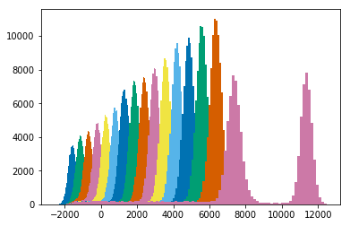

```python
fig, ax = plt.subplots()
for key in e_34s:
    ax.hist(e_34s[key]['Total Energy'], bins=100)
```

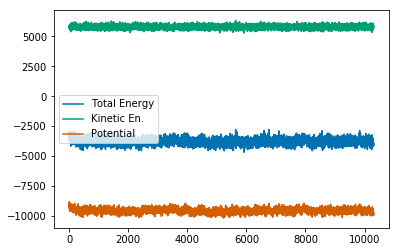

```python
e_npt_const = panedr.edr_to_df('12-NPT-PR-const/npt-298-out.edr')
e_npt_const[['Total Energy', 'Kinetic En.', 'Potential']].plot()
```

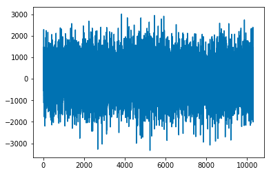

```python
e_npt_const.Pressure.plot()
```

## Look at some distances during a simulation

```python
u_12 = ca.Universe('gpx-cpa-sep.gro', '12-NPT-PR-rest/npt-298-out.xtc')
u_14 = ca.Universe('gpx-cpa-sep.gro', '14-equil-NPT-rest/npt-298-out.xtc')
u_15 = ca.Universe('gpx-cpa-sep.gro', '15-short-time/npt-298-out.xtc')
```

```
reaction distance mean: 2.23 and sd: 0.02
```

```
(<Figure size 864x288 with 2 Axes>,
 array([<matplotlib.axes._subplots.AxesSubplot object at 0x7f06913b9dd8>,
       dtype=object))
```

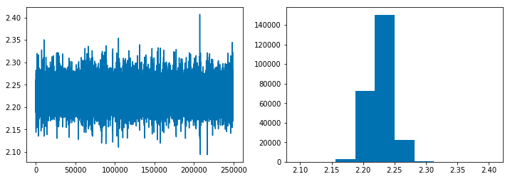

```python
plot_rd(u_12)
```

## Look at properties across all the simulations

```python
e_16s = dict()
for i in range(16):
    e_16s[i] = panedr.edr_to_df(f'16-PT-rest/PT-out{i}.edr')
```

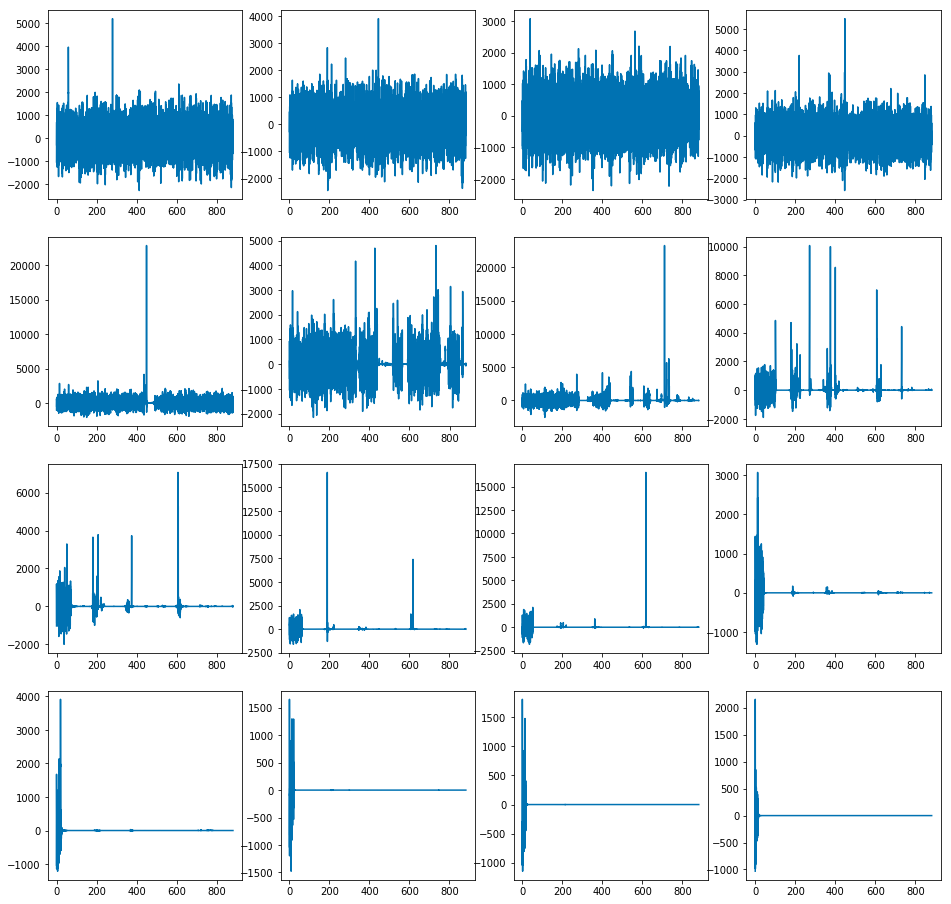

```python
fig, axes = plt.subplots(4, 4, figsize=(16,16))
for i in range(16):
    ax = axes.flat[i]
    e_16s[i].Pressure.plot(ax=ax)
```